# Robustness

Andrew Perfors

The goal of this is to determine when and to what extent true model parameters can be recovered for simulated posteriors when using different starting values.

## What can we vary?

Considering the analyses in the main paper, there are four things we can vary in our “ground truth” dataset: the reported prior, the likelihood (i.e., after five chips or unlimited chips), $\beta$, and $\gamma$. (We could also vary $\delta$ but in an effort to keep things simpler and since that was only a secondary analysis in the supplemental materials we will not do that yet.)

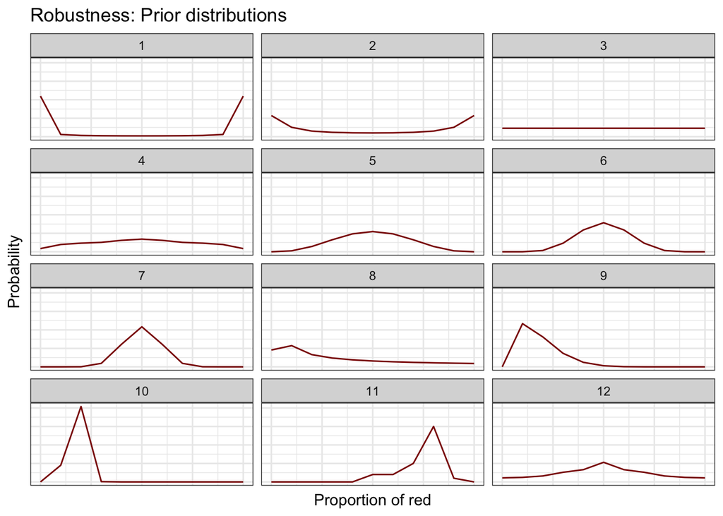

Then, for each prior we want to explore the range of possible $\beta$ and $\gamma$ values and what that means for the posterior.

Now we want to calculate the inferred gamma and beta for each of the n.

Now we want to see the accuracy of these things.

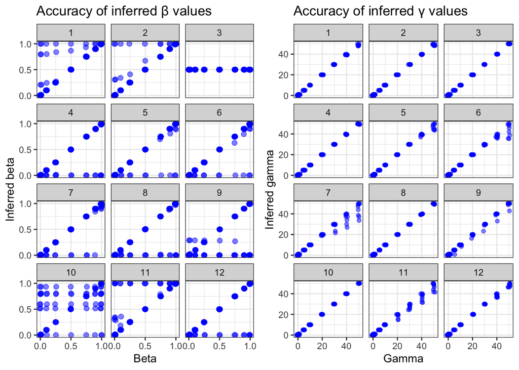

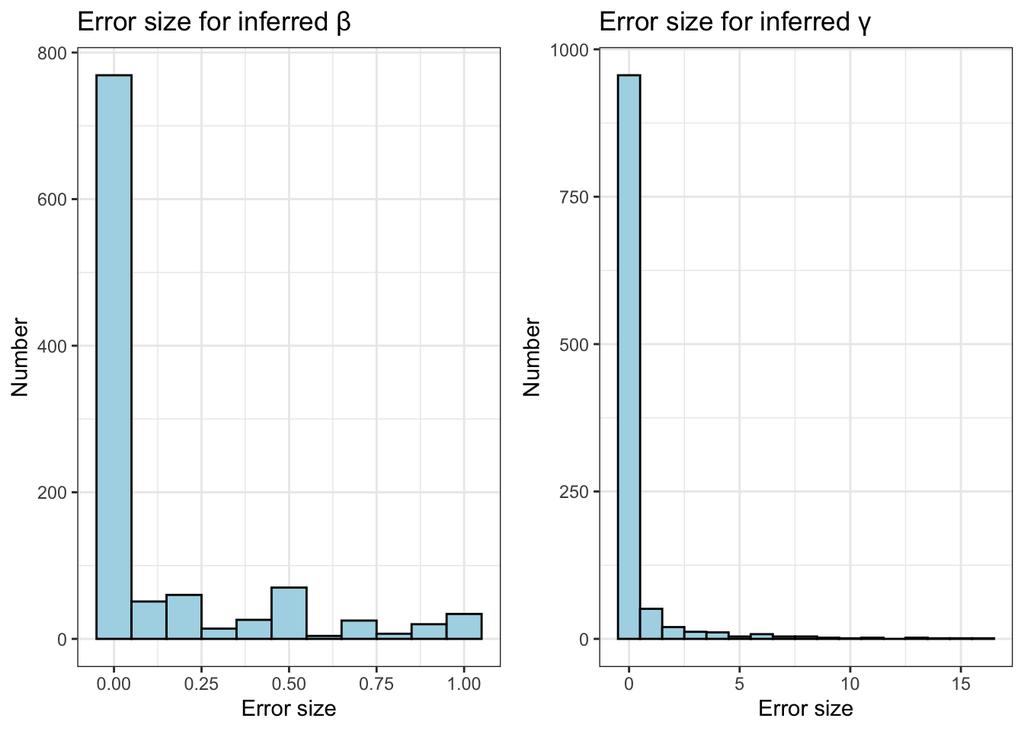

0.75 of the inferred beta were within 0.1 of it, and 0.85 of the inferred gamma were.

The main question at this point is where we are getting the poor accuracy for the $\beta$ values – for what kind of distributions and original beta/gamma value combinations is this?

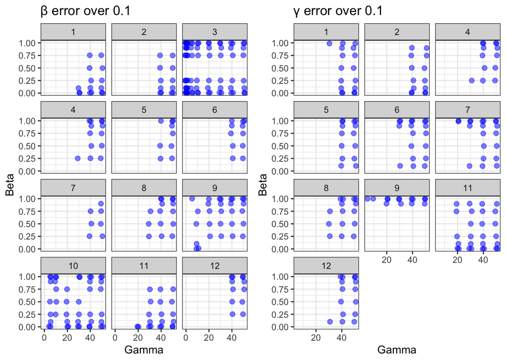

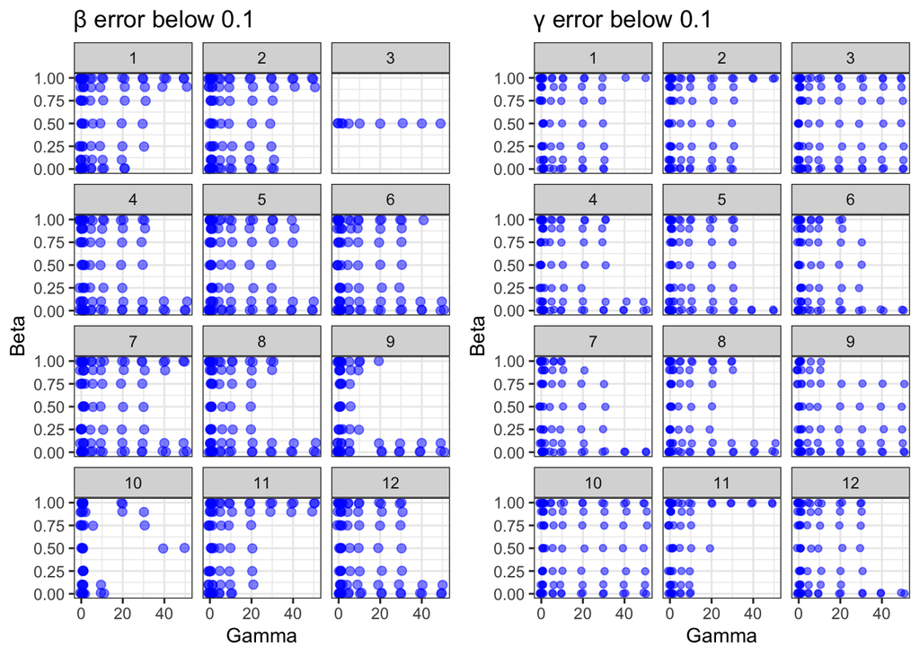